# Previsión de mantenimientos de maquinaria industrial en base a detección de eventos anómalos

Javier Muñoz García

18 de mayo, 2020

# Lectura del fichero y tipo de variables

En primer lugar, descargaremos el conjunto de datos, para este proyecto hemos utilizado el conjunto de datos de una máquina industrial que realiza mediciones y de donde disponemos sensores de temperatura y humedad. Los datos se han obtenido en la página web de [bigml](https://bigml.com/user/czuriaga/gallery/dataset/587d062d49c4a16936000810).

Una vez descargados los datos, procedemos a su lectura y revisión.

```r
# Carga de datos
data <- read.csv("C:/Users/Javier/Desktop/machine_failures.csv")
names(data) <- gsub("[^A-Za-z0-9]", "", names(data))

# Comprobación de datos cargados
head(data)
```

```
##                  Date Temperature Humidity  Operator Measure1 Measure2 Measure3
## 1 2016-01-01 00:00:00          67       82 Operator1      291        1        1
## 2 2016-01-01 01:00:00          68       77 Operator1     1180        1        1
## 3 2016-01-01 02:00:00          64       76 Operator1     1406        1        1
## 4 2016-01-01 03:00:00          63       80 Operator1      550        1        1
## 5 2016-01-01 04:00:00          65       81 Operator1     1928        1        2
## 6 2016-01-01 05:00:00          67       84 Operator1      398        1        2
##   Measure4 Measure5 Measure6 Measure7 Measure8 Measure9 Measure10 Measure11
## 1     1041      846      334      706     1086      256      1295       766
## 2     1915     1194      637     1093      524      919       245       403
## 3      511     1577     1121     1948     1882     1301       273      1927
## 4     1754     1834     1413     1151      945     1312      1494      1755
## 5     1326     1082      233     1441     1736     1033      1549       802
## 6     1901     1801     1153     1085     1547     2005       477      1217
##   Measure12 Measure13 Measure14 Measure15 HoursSincePreviousFailure Failure
```

[output cut: 20 more lines]

```r
# Tipos de variables
types <- sapply(data, class)
kable(data.frame(Variables = names(types), Clase = as.vector(types)))
```

| Variables | Clase |
| --- | --- |
| Date | factor |
| Temperature | integer |
| Humidity | integer |
| Operator | factor |
| Measure1 | integer |
| Measure2 | integer |
| Measure3 | integer |
| Measure4 | integer |
| Measure5 | integer |
| Measure6 | integer |
| Measure7 | integer |
| Measure8 | integer |
| Measure9 | integer |
| Measure10 | integer |
| Measure11 | integer |
| Measure12 | integer |
| Measure13 | integer |
| Measure14 | integer |
| Measure15 | integer |
| HoursSincePreviousFailure | integer |
| Failure | factor |
| Dateyear | integer |
| Datemonth | integer |
| Datedayofmonth | integer |
| Datedayofweek | integer |
| Datehour | integer |
| Dateminute | integer |
| Datesecond | integer |

En la revisión, hemos comprobado que algunos parámetros no coinciden con los esperados - los tipos de datos vienen especificados de origen - así que procedemos a cambiarlos.

```r
#Conversión de datos
data$Date <- as.POSIXct(data$Date, format = "%Y-%m-%d %H:%M:%S", tz="GMT")
data$Measure2 <- as.factor(data$Measure2)
data$Measure3 <- as.factor(data$Measure3)

# Tipos de variables
str(data)
```

```
## 'data.frame':    8784 obs. of  28 variables:
##  $ Date                     : POSIXct, format: "2016-01-01 00:00:00" "2016-01-01 01:00:00" ...
##  $ Temperature              : int  67 68 64 63 65 67 67 67 65 63 ...
##  $ Humidity                 : int  82 77 76 80 81 84 83 76 80 80 ...
##  $ Operator                 : Factor w/ 8 levels "Operator1","Operator2",..: 1 1 1 1 1 1 1 1 3 3 ...
##  $ Measure1                 : int  291 1180 1406 550 1928 398 847 1021 1731 415 ...
##  $ Measure2                 : Factor w/ 4 levels "0","1","2","3": 2 2 2 2 2 2 1 3 3 1 ...
##  $ Measure3                 : Factor w/ 3 levels "0","1","2": 2 2 2 2 3 3 3 2 1 1 ...
##  $ Measure4                 : int  1041 1915 511 1754 1326 1901 1849 185 1424 1008 ...
##  $ Measure5                 : int  846 1194 1577 1834 1082 1801 1141 170 1176 1086 ...
##  $ Measure6                 : int  334 637 1121 1413 233 1153 1609 952 1223 1759 ...
##  $ Measure7                 : int  706 1093 1948 1151 1441 1085 982 1183 621 1946 ...
##  $ Measure8                 : int  1086 524 1882 945 1736 1547 1159 1329 647 1814 ...
##  $ Measure9                 : int  256 919 1301 1312 1033 2005 672 427 369 1754 ...
##  $ Measure10                : int  1295 245 273 1494 1549 477 1128 1638 239 1442 ...
##  $ Measure11                : int  766 403 1927 1755 802 1217 663 850 1196 341 ...
##  $ Measure12                : int  968 723 1123 1434 1819 1632 1114 379 1944 1097 ...
##  $ Measure13                : int  1185 1446 717 502 1616 1324 1838 1529 1583 1819 ...
##  $ Measure14                : int  1355 719 1518 1336 1507 1854 290 755 1630 472 ...
##  $ Measure15                : int  1842 748 1689 711 507 1739 1192 844 237 491 ...
##  $ HoursSincePreviousFailure: int  90 91 92 93 94 95 96 97 98 99 ...
##  $ Failure                  : Factor w/ 2 levels "No","Yes": 1 1 1 1 1 1 1 1 1 1 ...
##  $ Dateyear                 : int  2016 2016 2016 2016 2016 2016 2016 2016 2016 2016 ...
##  $ Datemonth                : int  1 1 1 1 1 1 1 1 1 1 ...
##  $ Datedayofmonth           : int  1 1 1 1 1 1 1 1 1 1 ...
##  $ Datedayofweek            : int  5 5 5 5 5 5 5 5 5 5 ...
##  $ Datehour                 : int  0 1 2 3 4 5 6 7 8 9 ...
##  $ Dateminute               : int  0 0 0 0 0 0 0 0 0 0 ...
##  $ Datesecond               : int  0 0 0 0 0 0 0 0 0 0 ...
```

# Estadística descriptiva y visualización

Ahora que tenemos el conjunto de datos correctamente cargado, vamos a ver la información básica de las variables y como están distribuidas, además de comprobar si algún valor nulo o vacío.

```r
# Información básica
summary(data)
```

```
##       Date                      Temperature       Humidity
##  Min.   :2016-01-01 00:00:00   Min.   : 5.00   Min.   : 65.00
##  1st Qu.:2016-04-01 11:45:00   1st Qu.:62.00   1st Qu.: 80.00
##  Median :2016-07-01 23:30:00   Median :64.00   Median : 83.00
##  Mean   :2016-07-01 23:30:00   Mean   :64.03   Mean   : 83.34
##  3rd Qu.:2016-10-01 11:15:00   3rd Qu.:66.00   3rd Qu.: 87.00
##  Max.   :2016-12-31 23:00:00   Max.   :78.00   Max.   :122.00
##
##       Operator       Measure1    Measure2 Measure3    Measure4
##  Operator2:1952   Min.   : 155   0:2227   0:2931   Min.   : 155.0
##  Operator1: 976   1st Qu.: 629   1:2168   1:2929   1st Qu.: 608.8
##  Operator3: 976   Median :1096   2:2248   2:2924   Median :1058.0
##  Operator4: 976   Mean   :1091   3:2141            Mean   :1071.6
##  Operator5: 976   3rd Qu.:1555                     3rd Qu.:1533.0
##  Operator6: 976   Max.   :2011                     Max.   :2011.0
##  (Other)  :1952
##     Measure5       Measure6       Measure7       Measure8       Measure9
##  Min.   : 155   Min.   : 155   Min.   : 155   Min.   : 155   Min.   : 155
##  1st Qu.: 606   1st Qu.: 623   1st Qu.: 621   1st Qu.: 612   1st Qu.: 631
##  Median :1077   Median :1072   Median :1089   Median :1074   Median :1078
##  Mean   :1076   Mean   :1076   Mean   :1087   Mean   :1077   Mean   :1082
##  3rd Qu.:1541   3rd Qu.:1537   3rd Qu.:1558   3rd Qu.:1541   3rd Qu.:1532
##  Max.   :2011   Max.   :2011   Max.   :2011   Max.   :2011   Max.   :2011
##
##    Measure10      Measure11      Measure12      Measure13      Measure14
##  Min.   : 155   Min.   : 155   Min.   : 155   Min.   : 155   Min.   : 155
##  1st Qu.: 619   1st Qu.: 627   1st Qu.: 627   1st Qu.: 609   1st Qu.: 617
##  Median :1080   Median :1093   Median :1082   Median :1067   Median :1088
##  Mean   :1082   Mean   :1089   Mean   :1088   Mean   :1077   Mean   :1088
##  3rd Qu.:1547   3rd Qu.:1550   3rd Qu.:1552   3rd Qu.:1539   3rd Qu.:1560
##  Max.   :2011   Max.   :2011   Max.   :2011   Max.   :2011   Max.   :2011
##
##    Measure15    HoursSincePreviousFailure Failure       Dateyear
##  Min.   : 155   Min.   :  1.0             No :8703   Min.   :2016
##  1st Qu.: 614   1st Qu.: 90.0             Yes:  81   1st Qu.:2016
##  Median :1076   Median :195.0                        Median :2016
##  Mean   :1082   Mean   :217.3                        Mean   :2016
##  3rd Qu.:1550   3rd Qu.:324.0                        3rd Qu.:2016
##  Max.   :2011   Max.   :666.0                        Max.   :2016
##
##    Datemonth      Datedayofmonth  Datedayofweek      Datehour       Dateminute
##  Min.   : 1.000   Min.   : 1.00   Min.   :1.000   Min.   : 0.00   Min.   :0
##  1st Qu.: 4.000   1st Qu.: 8.00   1st Qu.:2.000   1st Qu.: 5.75   1st Qu.:0
##  Median : 7.000   Median :16.00   Median :4.000   Median :11.50   Median :0
##  Mean   : 6.514   Mean   :15.76   Mean   :4.008   Mean   :11.50   Mean   :0
##  3rd Qu.:10.000   3rd Qu.:23.00   3rd Qu.:6.000   3rd Qu.:17.25   3rd Qu.:0
##  Max.   :12.000   Max.   :31.00   Max.   :7.000   Max.   :23.00   Max.   :0
##
##    Datesecond
##  Min.   :0
##  1st Qu.:0
##  Median :0
##  Mean   :0
##  3rd Qu.:0
##  Max.   :0
##
```

```r
#Comprobación de valores nulos
cat("\nValores nulos en el conjunto de datos:", toString(sum(is.na(data))), "\n" )
```

```
##
## Valores nulos en el conjunto de datos: 0
```

**Variables cualitativas.** Para las variables categóricas, veremos simplemente un digrama de tarta para ver su distribución.

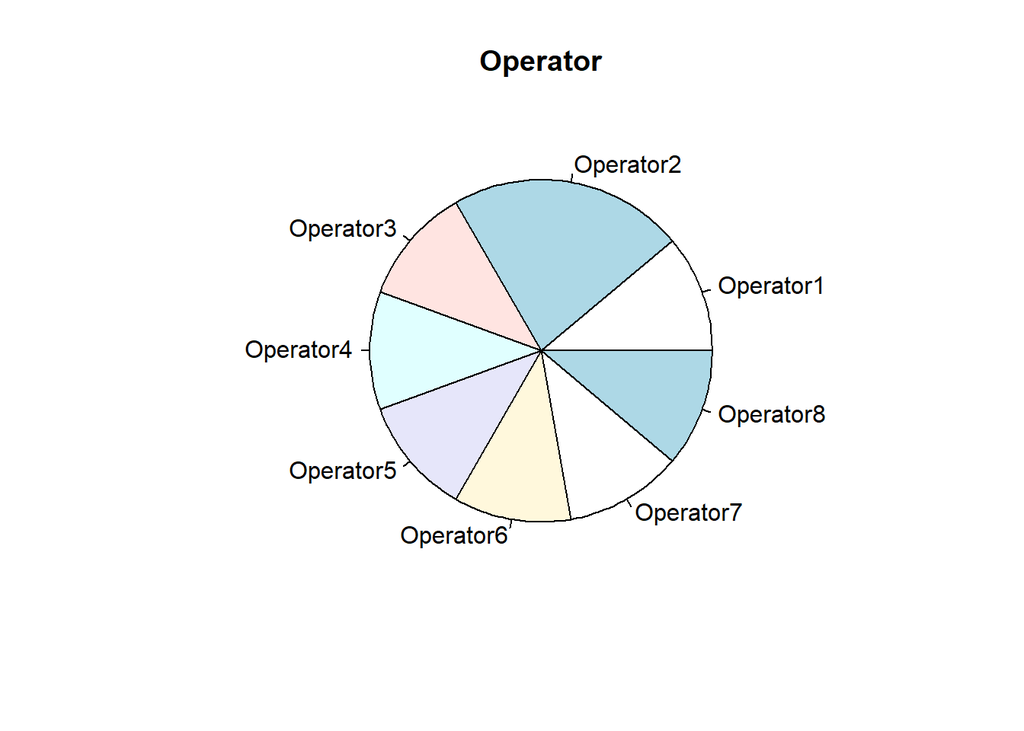

```r
# Operator
pie(table(data$Operator), main = 'Operator')
```

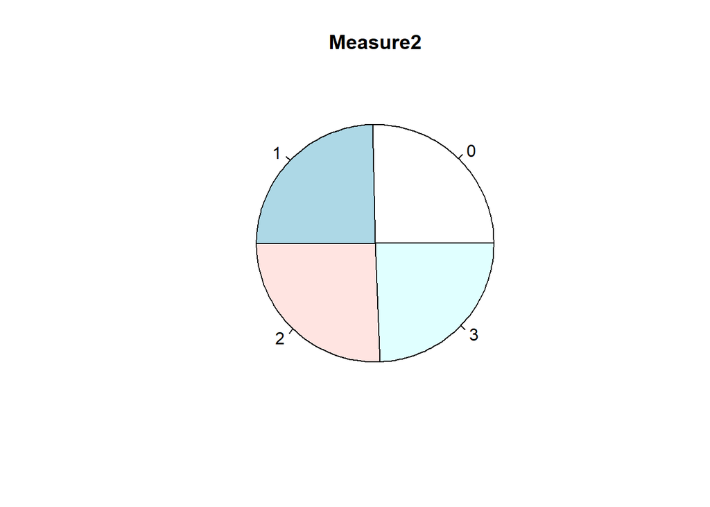

```r
# Measure2
pie(table(data$Measure2), main = 'Measure2')
```

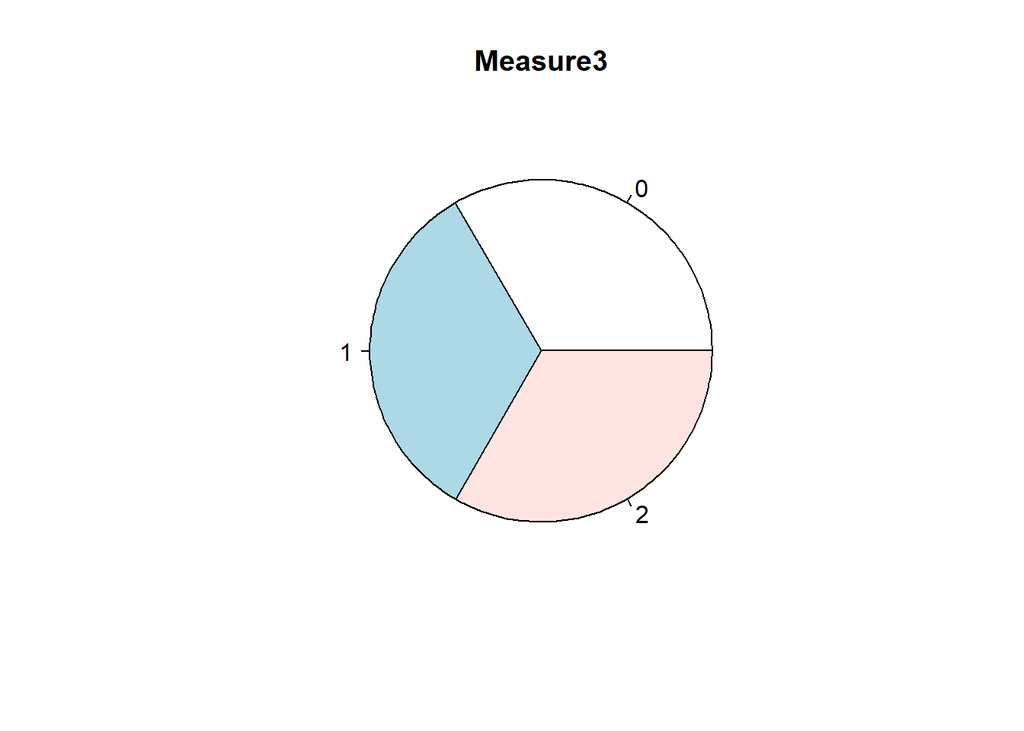

```r
# Measure3
pie(table(data$Measure3), main = 'Measure3')
```

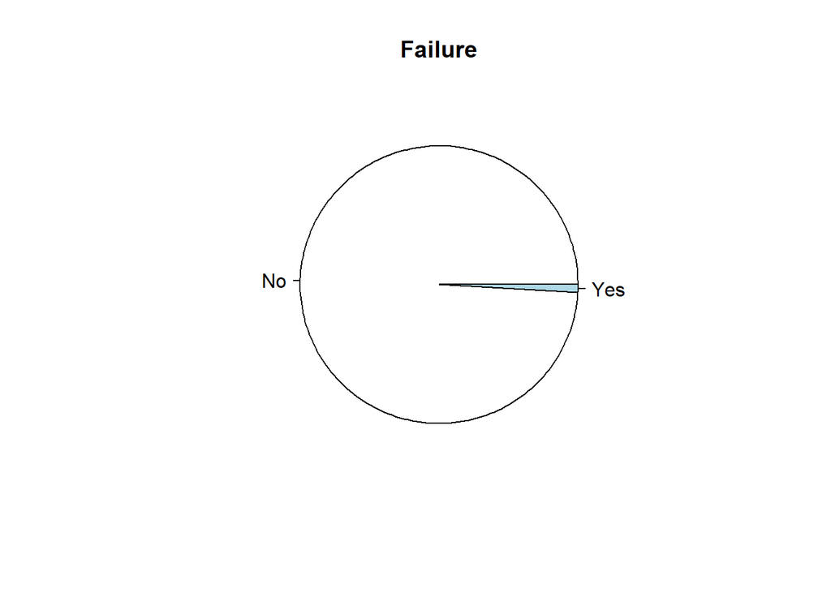

```r
# Failure
pie(table(data$Failure), main = 'Failure')
```

**Variables cuantitativas.** A conituanición, mostraremos las variables ‘propias’ de este problema con diagramas de caja, con el que podremos ver su distribución.

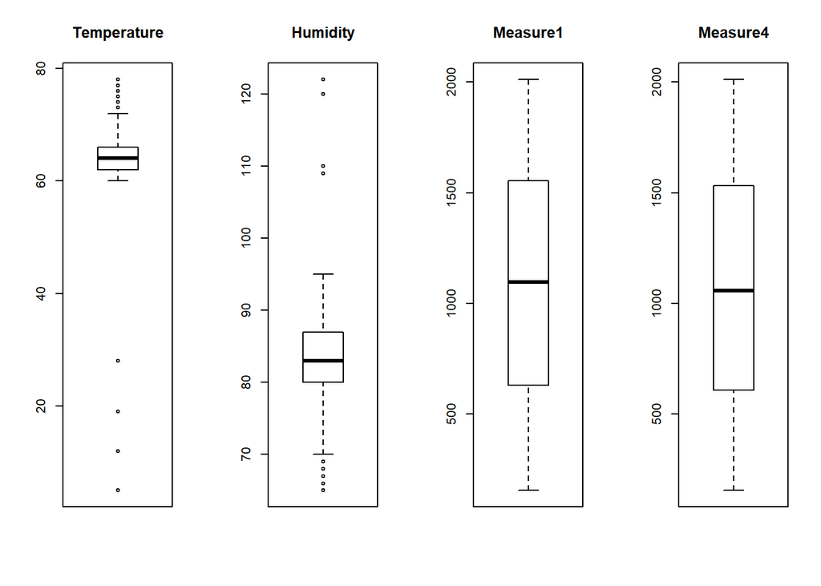

```r
par(mfrow = c(1, 4))
# Temperature
boxplot(data$Temperature, main = 'Temperature')
# Humidity
boxplot(data$Humidity, main = 'Humidity')
# Measure1
boxplot(data$Measure1, main = 'Measure1')
# Measure4
boxplot(data$Measure4, main = 'Measure4')
```

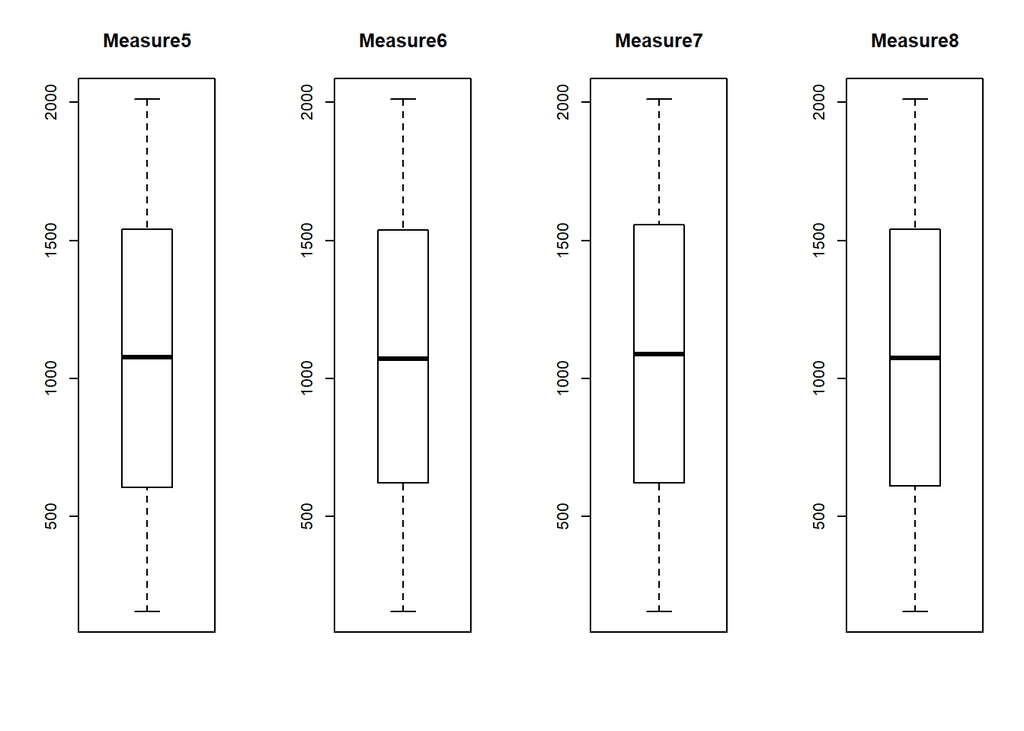

```r
# Measure5
boxplot(data$Measure5, main = 'Measure5')
# Measure6
boxplot(data$Measure6, main = 'Measure6')
# Measure7
boxplot(data$Measure7, main = 'Measure7')
# Measure8
boxplot(data$Measure8, main = 'Measure8')
```

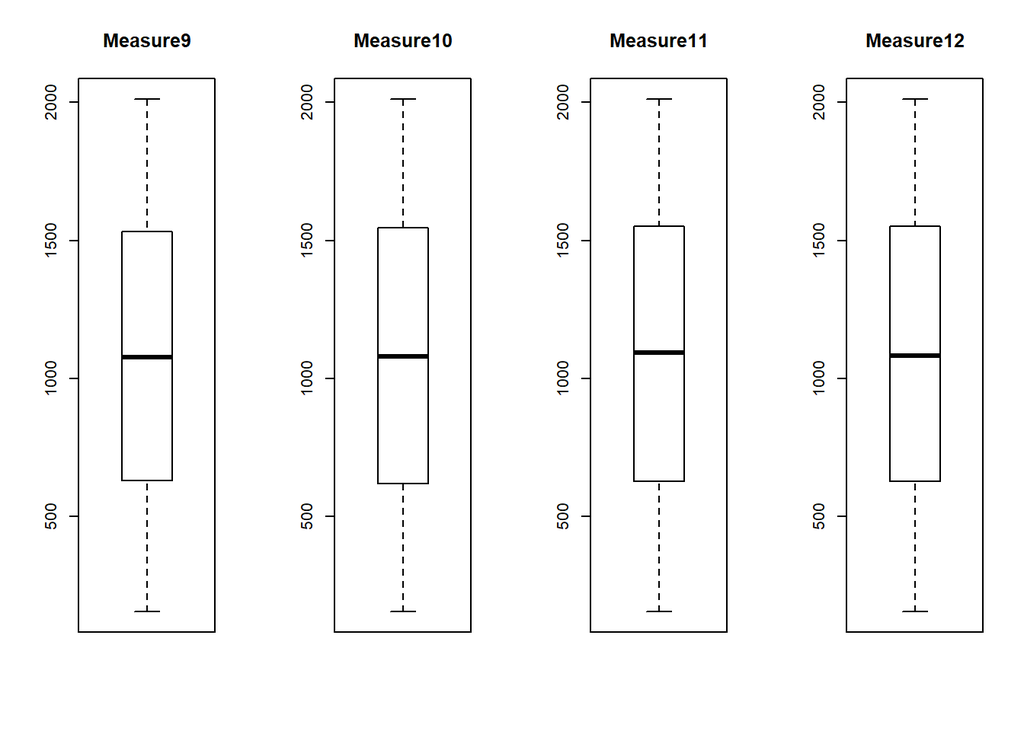

```r
# Measure9
boxplot(data$Measure9, main = 'Measure9')
# Measure10
boxplot(data$Measure10, main = 'Measure10')
# Measure11
boxplot(data$Measure11, main = 'Measure11')
# Measure12
boxplot(data$Measure12, main = 'Measure12')
```

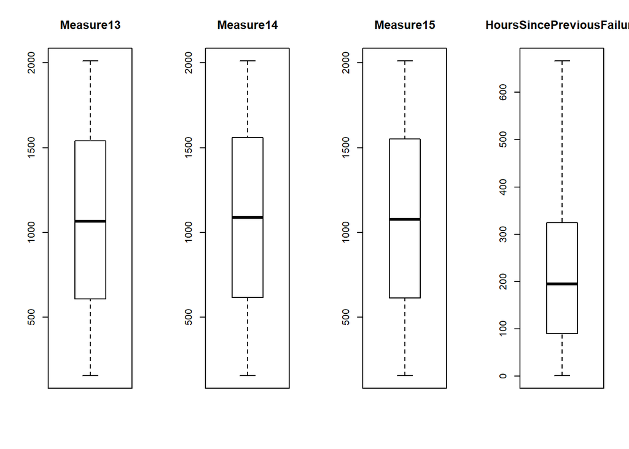

```r
# Measure13
boxplot(data$Measure13, main = 'Measure13')
# Measure14
boxplot(data$Measure14, main = 'Measure14')
# Measure15
boxplot(data$Measure15, main = 'Measure15')
# HoursSincePreviousFailure
boxplot(data$HoursSincePreviousFailure, main = 'HoursSincePreviousFailure')
```

Por último, mostraremos un historiograma con la fecha de estas observaciones.

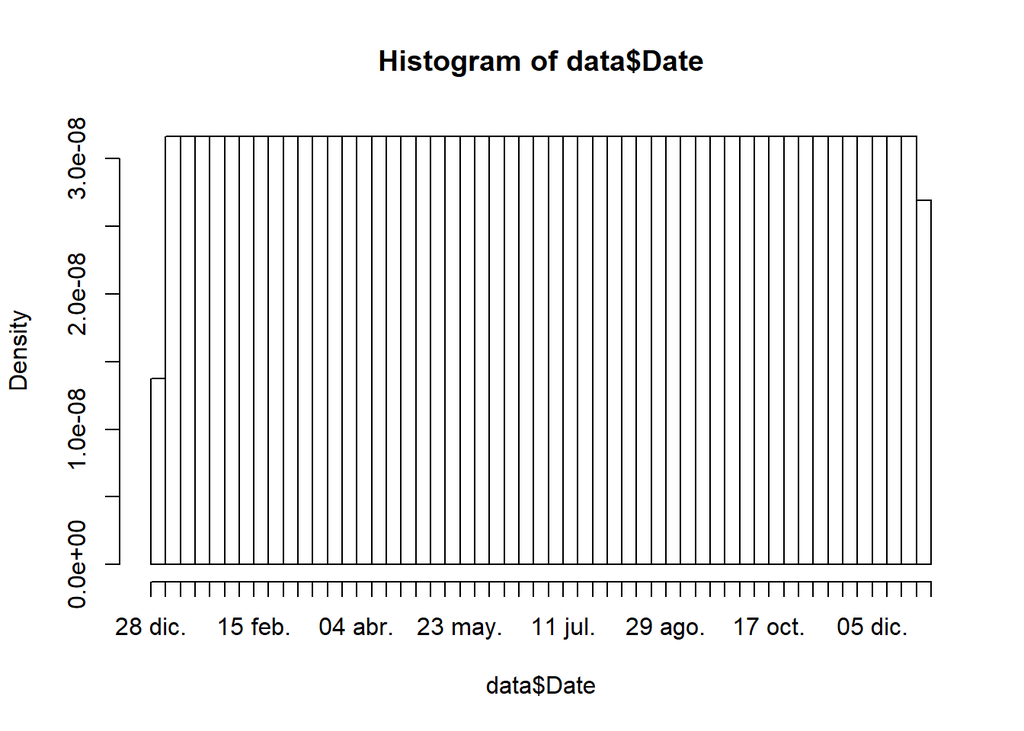

```r
# Date
hist(data$Date, "weeks", format = "%d %b")
```

# Valores extremos

Con el apartado anterior, hemos podido ver que las variables de **Temperatura** y **Humedad** presentan valores extremos, por lo que debemos decidir si estos valores son reales o son debidos a un error.

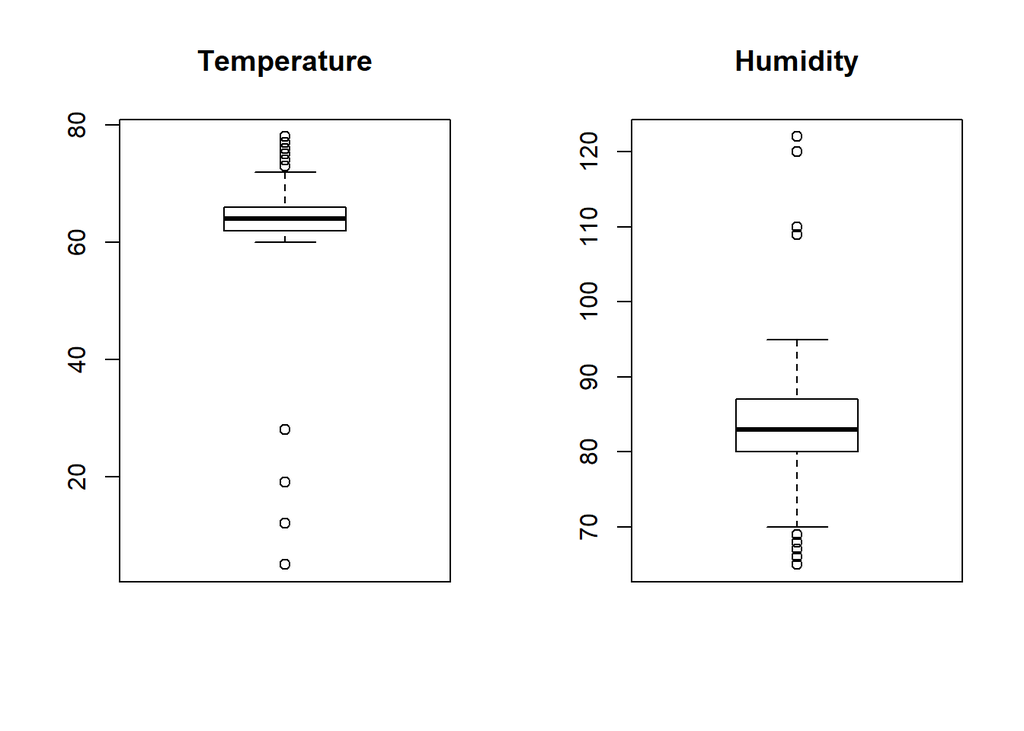

```r
par(mfrow = c(1, 2))
# Temperature
boxplot(data$Temperature, main = 'Temperature')
# Humidity
boxplot(data$Humidity, main = 'Humidity')
```

Comenzaremos por la temperatura, extrayendo los valores considerados como extremos.

```r
values <- boxplot.stats(data$Temperature)$out
#Valores extremos y sus posiciones:
cat("Valores extremos en Temperatura:", toString(values), "\n" )
```

```
## Valores extremos en Temperatura: 12, 73, 73, 28, 75, 73, 74, 73, 19, 77, 73, 73, 75, 75, 76, 74, 74, 5, 73, 78, 75, 77, 76, 77
```

Ahora que sabemos cuales son los valores extremos, vamos a ver estos valores con la serie temporal para determinar si son valores posibles o si se trata de errores en la captación de datos.

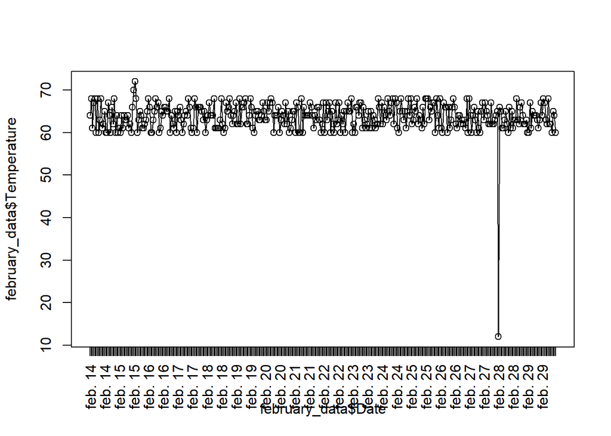

```r
#Examinamos un subconjunto de datos donde se muestren los valores extremos.
february_data <- data[data$Datemonth == 2 & data$Datedayofmonth > 13,]
plot(february_data$Date, february_data$Temperature, xaxt="n", type = "o")
axis.POSIXct(1, at=february_data$Date, las=2)
```

Parece que los valores bajos son muy extremos teniendo en cuenta que tenemos un dato del sensor de manera horaria, como vemos en la gráfica, se desciende más de 50 grados en un único punto y parece completamente aleatorio, ahora veremos con más detalle los valores superiores, en concreto el valor de este mismo mes.

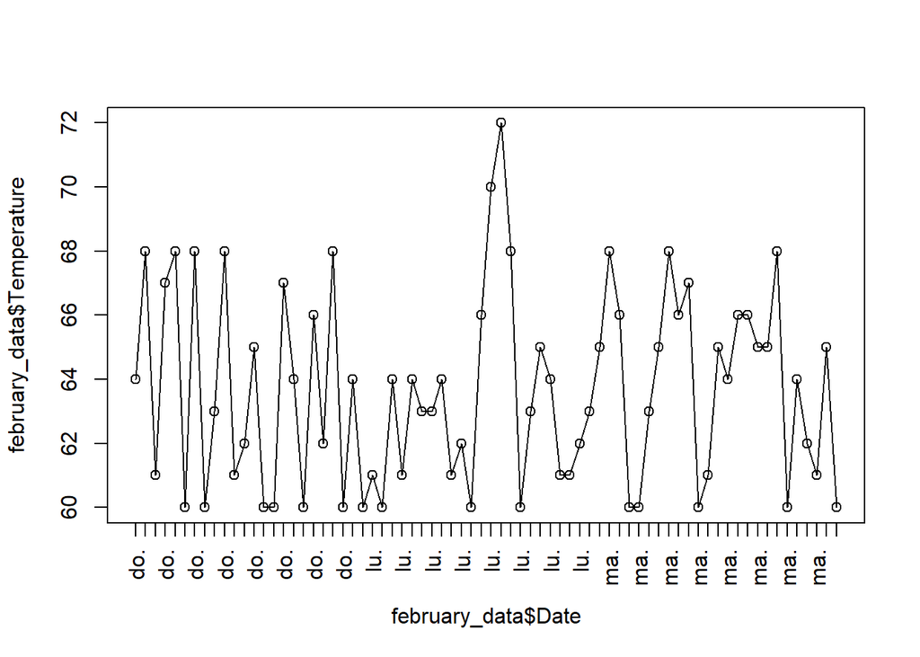

```r
#Examinamos un subconjunto específico del valor extremo superior para determinar si es correcto.
february_data <- data[data$Datemonth == 2 & data$Datedayofmonth > 13 & data$Datedayofmonth < 17,]
plot(february_data$Date, february_data$Temperature, xaxt="n", type = "o")
axis.POSIXct(1, at=february_data$Date, las=2)
```

A diferencia del valor anterior, éste si que puede estar al hilo de los demás ya que no difiere mucho de la normalidad y se aprecia la subida y bajada de temperatura paulatinamente, por lo que consideraremos valores válidos los valores superiores a la distribución normal.

```r
#Eliminamos de los valores extremos los valores superiores a 70, ya que los consideramos válidos.
idx <- which(data$Temperature %in% values & data$Temperature < 60)
data[idx,]
```

```
##                     Date Temperature Humidity  Operator Measure1 Measure2
## 1393 2016-02-28 00:00:00          12       79 Operator2     1975        1
## 3317 2016-05-18 04:00:00          28       82 Operator1     1686        3
## 4945 2016-07-25 00:00:00          19       88 Operator7      344        1
## 6721 2016-10-07 00:00:00           5       85 Operator2     1108        2
##      Measure3 Measure4 Measure5 Measure6 Measure7 Measure8 Measure9 Measure10
## 1393        2      958     1945      155      827     1099     1400       451
## 3317        2     1360      951      959      353     1394     1077      1126
## 4945        2     1519      859     1237      166     1642      243      1932
## 6721        1      866     1037     1265     1282     1946      490      1136
##      Measure11 Measure12 Measure13 Measure14 Measure15
## 1393      1694      1998      1885       398      1383
## 3317      1962       870       189       357       843
## 4945       217       515       887      1093      1157
## 6721      1935      1839      1042      1198       861
##      HoursSincePreviousFailure Failure Dateyear Datemonth Datedayofmonth
## 1393                       279      No     2016         2             28
## 3317                       140      No     2016         5             18
## 4945                       348      No     2016         7             25
## 6721                       270      No     2016        10              7
##      Datedayofweek Datehour Dateminute Datesecond
## 1393             7        0          0          0
## 3317             3        4          0          0
## 4945             1        0          0          0
## 6721             5        0          0          0
```

```r
data[idx,]$Temperature <- NA
data[idx,]
```

```
##                     Date Temperature Humidity  Operator Measure1 Measure2
## 1393 2016-02-28 00:00:00          NA       79 Operator2     1975        1
## 3317 2016-05-18 04:00:00          NA       82 Operator1     1686        3
## 4945 2016-07-25 00:00:00          NA       88 Operator7      344        1
## 6721 2016-10-07 00:00:00          NA       85 Operator2     1108        2
##      Measure3 Measure4 Measure5 Measure6 Measure7 Measure8 Measure9 Measure10
## 1393        2      958     1945      155      827     1099     1400       451
## 3317        2     1360      951      959      353     1394     1077      1126
## 4945        2     1519      859     1237      166     1642      243      1932
## 6721        1      866     1037     1265     1282     1946      490      1136
##      Measure11 Measure12 Measure13 Measure14 Measure15
## 1393      1694      1998      1885       398      1383
## 3317      1962       870       189       357       843
## 4945       217       515       887      1093      1157
## 6721      1935      1839      1042      1198       861
##      HoursSincePreviousFailure Failure Dateyear Datemonth Datedayofmonth
## 1393                       279      No     2016         2             28
## 3317                       140      No     2016         5             18
## 4945                       348      No     2016         7             25
## 6721                       270      No     2016        10              7
##      Datedayofweek Datehour Dateminute Datesecond
## 1393             7        0          0          0
## 3317             3        4          0          0
## 4945             1        0          0          0
## 6721             5        0          0          0
```

Ahora procederemos a la imputación de los valores nulos con los 3 vecinos más cercanos usando la distancia de Gower, usando sólo la información de las variables cuantitativas y los datos del mismo mes.

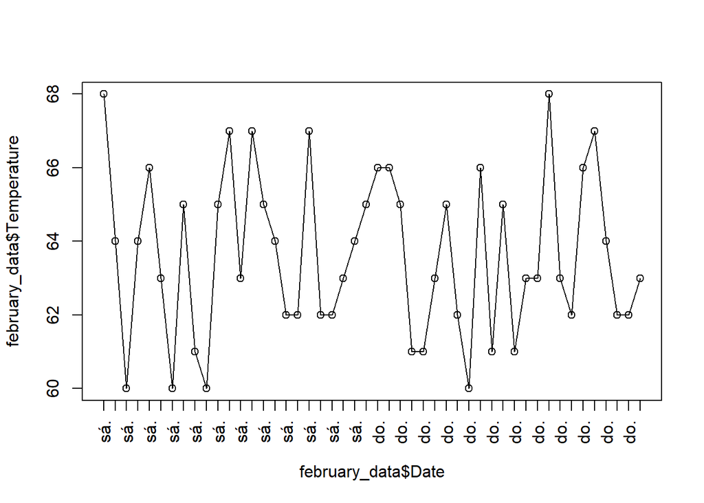

```r
#Todos los datos con NA pertenecen a diferentes meses.
#Para mejor generalización y aplicabilidad del código, se seleccionan los datos
#del conjunto del mismo mes y se realiza la imputación.
selected_reg <- which(data$Datemonth==2)
selected_vars <- c("Temperature","Humidity","Measure1","Measure4","Measure5","Measure6","Measure7","Measure8","Measure9","Measure10","Measure11","Measure12","Measure13","Measure14","Measure15","HoursSincePreviousFailure")
#Imputación con distancia de Gower:
output <- kNN(data[selected_reg, selected_vars], variable="Temperature", k=3)
data[idx[1],]$Temperature <- output[output$Temperature_imp==TRUE,]$Temperature

#Repetimos los pasos para los demás meses
selected_reg <- which(data$Datemonth==5)
output <- kNN(data[selected_reg, selected_vars], variable="Temperature", k=3)
data[idx[2],]$Temperature <- output[output$Temperature_imp==TRUE,]$Temperature

selected_reg <- which(data$Datemonth==7)
output <- kNN(data[selected_reg, selected_vars], variable="Temperature", k=3)
data[idx[3],]$Temperature <- output[output$Temperature_imp==TRUE,]$Temperature

selected_reg <- which(data$Datemonth==10)
output <- kNN(data[selected_reg, selected_vars], variable="Temperature", k=3)
data[idx[4],]$Temperature <- output[output$Temperature_imp==TRUE,]$Temperature

#Examinamos de nuevo el conjunto con el valor extremo, para ver si la imputación
#es consistente
february_data <- data[data$Datemonth == 2 & data$Datedayofmonth > 26 & data$Datedayofmonth < 29,]
plot(february_data$Date, february_data$Temperature, xaxt="n", type = "o")
axis.POSIXct(1, at=february_data$Date, las=2)
```

Ahora procederemos a realizar el mismo procedimiento con el parámetro de **Humedad**.

```r
values <- boxplot.stats(data$Humidity)$out
#Valores extremos y sus posiciones:
cat("Valores extremos en Humedad:", toString(values), "\n" )
```

```
## Valores extremos en Humedad: 110, 65, 67, 68, 65, 69, 69, 69, 109, 67, 69, 122, 69, 69, 68, 66, 69, 110, 69, 68, 69, 65, 120, 69, 69
```

Dado que la humedad se mide en porcentaje, entendemos que únicamente los valores por encima de 100 son erroneos.

```r
#En esta ocasión, sabemos que los valores superiores a 100 son incorrectos.
idx <- which(data$Humidity %in% values & data$Humidity > 100)
data[idx,]
```

```
##                     Date Temperature Humidity  Operator Measure1 Measure2
## 61   2016-01-03 12:00:00          64      110 Operator2     1311        2
## 2578 2016-04-17 09:00:00          65      109 Operator2      871        3
## 4502 2016-07-06 13:00:00          63      122 Operator4      441        3
## 6649 2016-10-04 00:00:00          64      110 Operator2     1773        0
## 8056 2016-12-01 15:00:00          65      120 Operator2     1947        3
##      Measure3 Measure4 Measure5 Measure6 Measure7 Measure8 Measure9 Measure10
## 61          1     1179     1001      277     1679     1266     1236       527
## 2578        2     1468      252     1751      704     1544      919       548
## 4502        0      730     1834      556      987      219     1025      1500
## 6649        2     1640     1081      838      386     1966     1256      1213
## 8056        0     1200     1020     1060     1228     1154      882      1929
##      Measure11 Measure12 Measure13 Measure14 Measure15
## 61         987      1296       678      1234      1850
## 2578       405       340       537      1091      1790
## 4502      1978      1556       621       201       826
## 6649       809      1293       776       823       976
## 8056      1428       550       166      1366      1606
##      HoursSincePreviousFailure Failure Dateyear Datemonth Datedayofmonth
## 61                         150      No     2016         1              3
## 2578                       148      No     2016         4             17
## 4502                       277      No     2016         7              6
## 6649                       198      No     2016        10              4
## 8056                       541      No     2016        12              1
##      Datedayofweek Datehour Dateminute Datesecond
## 61               7       12          0          0
## 2578             7        9          0          0
## 4502             3       13          0          0
## 6649             2        0          0          0
## 8056             4       15          0          0
```

```r
data[idx,]$Humidity <- NA
data[idx,]
```

```
##                     Date Temperature Humidity  Operator Measure1 Measure2
## 61   2016-01-03 12:00:00          64       NA Operator2     1311        2
## 2578 2016-04-17 09:00:00          65       NA Operator2      871        3
## 4502 2016-07-06 13:00:00          63       NA Operator4      441        3
## 6649 2016-10-04 00:00:00          64       NA Operator2     1773        0
## 8056 2016-12-01 15:00:00          65       NA Operator2     1947        3
##      Measure3 Measure4 Measure5 Measure6 Measure7 Measure8 Measure9 Measure10
## 61          1     1179     1001      277     1679     1266     1236       527
## 2578        2     1468      252     1751      704     1544      919       548
## 4502        0      730     1834      556      987      219     1025      1500
## 6649        2     1640     1081      838      386     1966     1256      1213
## 8056        0     1200     1020     1060     1228     1154      882      1929
##      Measure11 Measure12 Measure13 Measure14 Measure15
## 61         987      1296       678      1234      1850
## 2578       405       340       537      1091      1790
## 4502      1978      1556       621       201       826
## 6649       809      1293       776       823       976
## 8056      1428       550       166      1366      1606
##      HoursSincePreviousFailure Failure Dateyear Datemonth Datedayofmonth
## 61                         150      No     2016         1              3
## 2578                       148      No     2016         4             17
## 4502                       277      No     2016         7              6
## 6649                       198      No     2016        10              4
## 8056                       541      No     2016        12              1
##      Datedayofweek Datehour Dateminute Datesecond
## 61               7       12          0          0
## 2578             7        9          0          0
## 4502             3       13          0          0
## 6649             2        0          0          0
## 8056             4       15          0          0
```

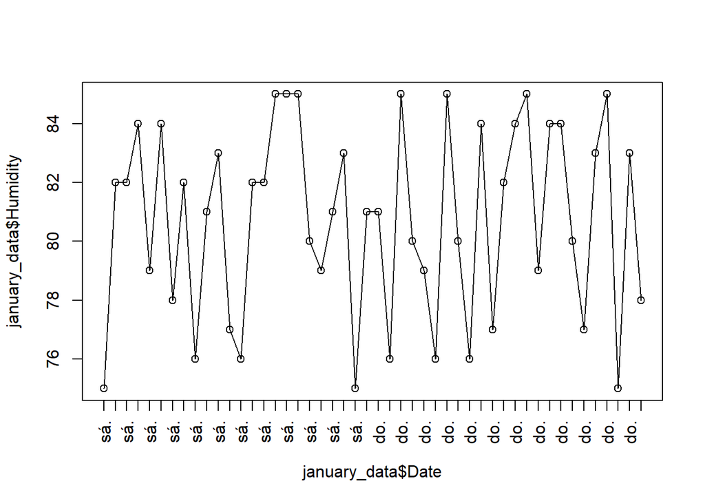

```r
#Todos los datos con NA pertenecen a diferentes meses.
#Realizaremos el mismo procedimiento que con la temperatura.
selected_reg <- which(data$Datemonth==1)
output <- kNN(data[selected_reg, selected_vars], variable="Humidity", k=3)
data[idx[1],]$Humidity <- output[output$Humidity_imp==TRUE,]$Humidity

selected_reg <- which(data$Datemonth==4)
output <- kNN(data[selected_reg, selected_vars], variable="Humidity", k=3)
data[idx[2],]$Humidity <- output[output$Humidity_imp==TRUE,]$Humidity

selected_reg <- which(data$Datemonth==7)
output <- kNN(data[selected_reg, selected_vars], variable="Humidity", k=3)
data[idx[3],]$Humidity <- output[output$Humidity_imp==TRUE,]$Humidity

selected_reg <- which(data$Datemonth==10)
output <- kNN(data[selected_reg, selected_vars], variable="Humidity", k=3)
data[idx[4],]$Humidity <- output[output$Humidity_imp==TRUE,]$Humidity

selected_reg <- which(data$Datemonth==12)
output <- kNN(data[selected_reg, selected_vars], variable="Humidity", k=3)
data[idx[5],]$Humidity <- output[output$Humidity_imp==TRUE,]$Humidity

#Examinamos de nuevo el conjunto con el valor extremo, para ver si la imputación
#es consistente
january_data <- data[data$Datemonth == 1 & data$Datedayofmonth > 1 & data$Datedayofmonth < 4,]
plot(january_data$Date, january_data$Humidity, xaxt="n", type = "o")
axis.POSIXct(1, at=january_data$Date, las=2)
```

# Selección de parámetros para el modelo

A continuación realizaremos una reducción de la dimensionaidad con el algoritmo de RandomForest y seleccionaremos las variables más influyentes en el fallo de la máquina.

```r
#Crearemos una semilla para que los resultados sean repetibles
set.seed(7)

selected_vars <- c("Temperature","Humidity","Measure1","Measure2","Measure3","Measure4","Measure5","Measure6","Measure7","Measure8","Measure9","Measure10","Measure11","Measure12","Measure13","Measure14","Measure15","HoursSincePreviousFailure","Datemonth","Datedayofweek","Datedayofmonth","Datehour")

data_features <- data[selected_vars]
data_target <- data[["Failure"]]

#Función de selección mediante RandomForest
control <- rfeControl(functions=rfFuncs, method="cv", number=10)
results <- rfe(data_features, data_target, sizes=c(1:22), rfeControl=control)

#Resultados
print(results)
```

```
##
## Recursive feature selection
##
## Outer resampling method: Cross-Validated (10 fold)
##
## Resampling performance over subset size:
##
##  Variables Accuracy  Kappa AccuracySD KappaSD Selected
##          1   0.9952 0.6874   0.001399 0.09115
##          2   0.9967 0.7998   0.001252 0.07449
##          3   0.9973 0.8299   0.001627 0.09920
##          4   0.9973 0.8337   0.001628 0.09844
##          5   0.9976 0.8559   0.001465 0.08532
##          6   0.9973 0.8313   0.001796 0.10696
##          7   0.9974 0.8361   0.001614 0.09939
##          8   0.9975 0.8433   0.001292 0.08177
##          9   0.9976 0.8500   0.001464 0.09206        *
##         10   0.9975 0.8443   0.001498 0.09344
##         11   0.9974 0.8345   0.001320 0.08496
##         12   0.9974 0.8345   0.001320 0.08496
##         13   0.9973 0.8278   0.001099 0.07210
##         14   0.9974 0.8335   0.001080 0.07179
##         15   0.9972 0.8189   0.001106 0.07365
##         16   0.9975 0.8433   0.001292 0.08177
##         17   0.9974 0.8366   0.001079 0.06927
##         18   0.9973 0.8278   0.001099 0.07210
##         19   0.9974 0.8335   0.001079 0.07178
##         20   0.9972 0.8189   0.001106 0.07365
##         21   0.9972 0.8158   0.001106 0.07523
##         22   0.9972 0.8189   0.001106 0.07365
##
## The top 5 variables (out of 9):
##    Humidity, Temperature, HoursSincePreviousFailure, Datemonth, Datedayofmonth
```

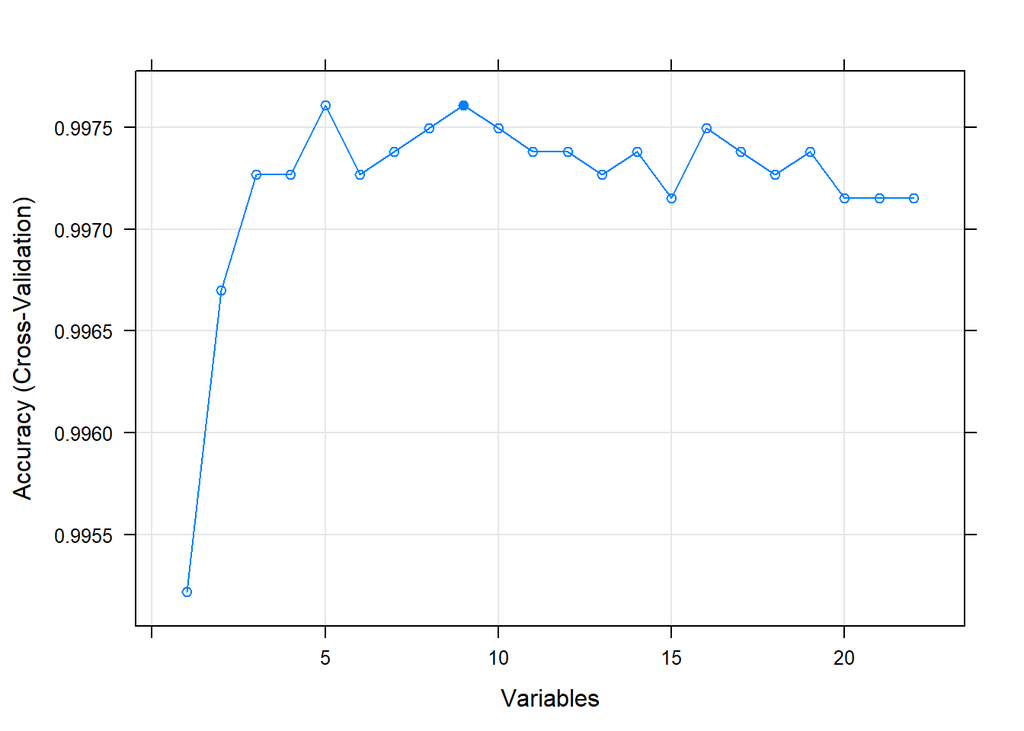

```r
 plot(results, type=c("g", "o"))
```

# Creación de modelos

Una vez seleccionadas las variables, procedemos a la creación de los modelos para evaluar si somos capaces de detectar el fallo de la máquina.

## Preparación de los conjuntos de entrenamiento y test

En primer lugar, utilizaremos la librería de H2O para realizar las pruebas.

Para ello, procedemos a inicializar la librería y establecer nuestro clúster (que será unicamente de un nodo) además de convertir nuestro conjunto de datos en uno del tipo H2O.

```r
h2o.init(nthreads = -1)
```

```
##  Connection successful!
##
## R is connected to the H2O cluster:
##     H2O cluster uptime:         2 hours 4 minutes
##     H2O cluster timezone:       Europe/Paris
##     H2O data parsing timezone:  UTC
##     H2O cluster version:        3.30.0.1
##     H2O cluster version age:    1 month and 14 days
##     H2O cluster name:           H2O_started_from_R_Javier_jsg195
##     H2O cluster total nodes:    1
##     H2O cluster total memory:   1.40 GB
##     H2O cluster total cores:    4
##     H2O cluster allowed cores:  4
##     H2O cluster healthy:        TRUE
##     H2O Connection ip:          localhost
##     H2O Connection port:        54321
##     H2O Connection proxy:       NA
##     H2O Internal Security:      FALSE
##     H2O API Extensions:         Amazon S3, Algos, AutoML, Core V3, TargetEncoder, Core V4
##     R Version:                  R version 3.6.2 (2019-12-12)
```

```r
h2o.removeAll()
h2o.no_progress()

#Seleccionaremos las variables elegidas por el RandomForest
data_3features <- data[c("Temperature","Humidity","HoursSincePreviousFailure","Failure")]

#Convertimos H2O
data_hf <- as.h2o(data_3features)
```

Ahora, separaremos el conjunto de datos en dos conjuntos diferentes, uno para entrenamiento y otro de test.

```r
splits <- h2o.splitFrame(data_hf,
                         ratios = 0.8,
                         seed = 42)

train  <- splits[[1]]
test <- splits[[2]]

response <- "Failure"
features <- setdiff(colnames(train), response)
```

## Modelo con IsolationForest

Comenzaremos creando un modelo básico utilizando el algoritmo de **IsolationForest**.

```r
isoforest <- h2o.isolationForest(
                model_id = "isoforest",
                training_frame = train,
                x              = features,
                max_depth      = 350,
                ntrees         = 500,
                sample_rate    = 0.9
             )
```

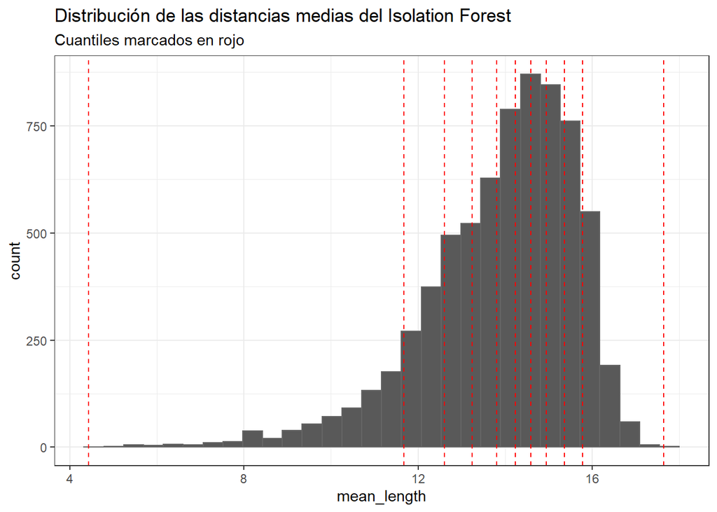

```r
predicciones_h2o <- h2o.predict(
                      object  = isoforest,
                      newdata = train
                    )
predicciones <- as.data.frame(predicciones_h2o)

ggplot(data = predicciones, aes(x = mean_length)) +
  geom_histogram(color = "gray40") +
  geom_vline(
    xintercept = quantile(predicciones$mean_length, seq(0, 1, 0.1)),
    color      = "red",
    linetype   = "dashed") +
  labs(
    title = "Distribución de las distancias medias del Isolation Forest",
    subtitle = "Cuantiles marcados en rojo"  ) +
  theme_bw()
```

Las distancias que hemos calculado servirán para identificar las anomalías - que serán aquellas con menor distancia promedio - y serán aquellas que se determinarán como fallo de máquina.

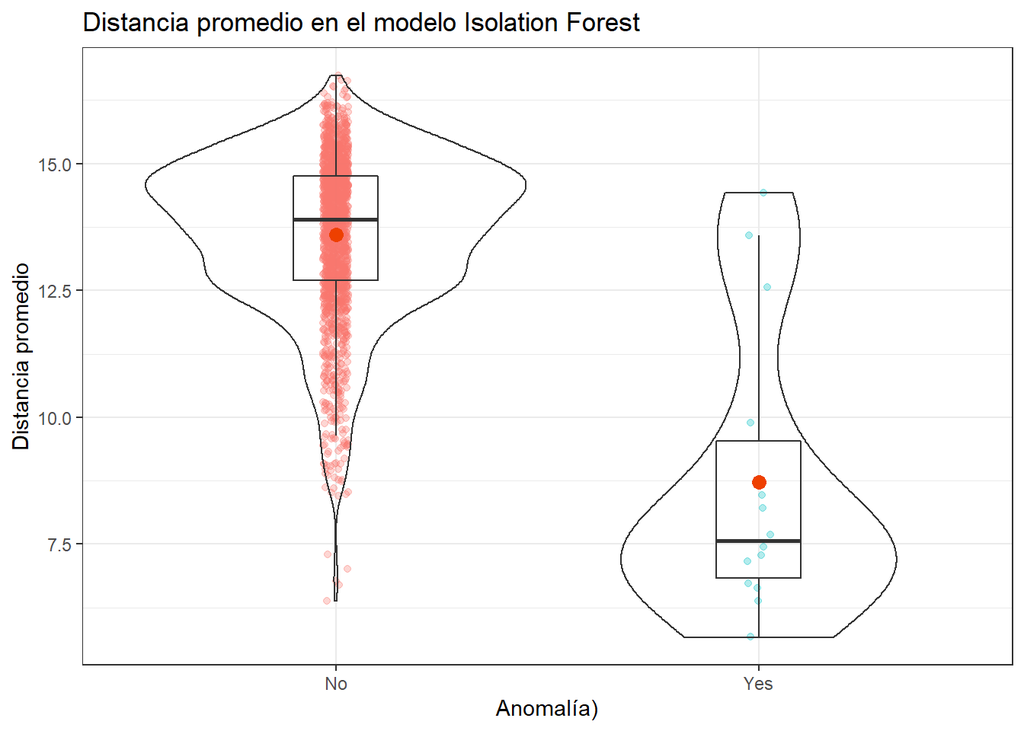

```r
predicciones_h2o_test <- h2o.predict(
                          object  = isoforest,
                          newdata = test
                        )
predicciones_test <- as.data.frame(predicciones_h2o_test)

resultados <- as.data.frame(test) %>%
         bind_cols(predicciones_test)

ggplot(data = resultados,
       aes(x = Failure, y = mean_length)) +
geom_jitter(aes(color = Failure), width = 0.03, alpha = 0.3) +
geom_violin(alpha = 0) +
geom_boxplot(width = 0.2, outlier.shape = NA, alpha = 0) +
stat_summary(fun = "mean", colour = "orangered2", size = 3, geom = "point") +
labs(title = "Distancia promedio en el modelo Isolation Forest",
     x = "Anomalía)",
     y = "Distancia promedio") +
theme_bw() +
theme(legend.position = "none")
```

```r
scoreLimit = quantile(as.vector(predicciones_h2o$pred), 0.995)
predicciones_h2o_test$scoreLimit <- scoreLimit

pred <- as.data.frame(predicciones_h2o_test) %>%
  mutate(actual = as.vector(test[, 4])) %>%
  mutate(predict = ifelse(predict > scoreLimit, "Yes", "No"))

pred %>%
  group_by(actual, predict) %>%
  summarise(n = n()) %>%
  mutate(freq = n / sum(n))
```

```
## # A tibble: 4 x 4
## # Groups:   actual [2]
##   actual predict     n    freq
##   <chr>  <chr>   <int>   <dbl>
## 1 No     No       1730 0.997
## 2 No     Yes         5 0.00288
## 3 Yes    No          7 0.5
## 4 Yes    Yes         7 0.5
```

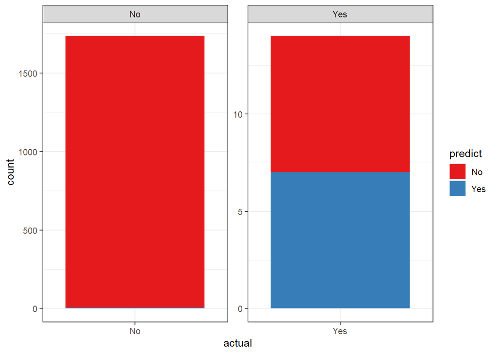

```r
pred %>%
  ggplot(aes(x = actual, fill = predict)) +
    geom_bar() +
    theme_bw() +
    scale_fill_brewer(palette = "Set1") +
    facet_wrap( ~ actual, scales = "free", ncol = 2)
```

## Modelo con Autoencoder

En esta ocasión explotaremos el modelo de autoencoder para también mostrar la diferencia entre un modelo supervisado y uno no supervisado, además de otras opciones del autoencoder.

### Detección de anomalías

La idea principal es utilizar una capa oculta muy pequeña para que el modelo tenga que reducir la dimensionalidad al mínimo - para poder, más adelante, utilizar esta capa - en este caso utilizaremos únicamente 2 nodos en esta capa.

```r
model_nn <- h2o.deeplearning(x = features,
                             training_frame = train,
                             model_id = "model_nn",
                             autoencoder = TRUE,
                             reproducible = TRUE,
                             ignore_const_cols = FALSE,
                             seed = 42,
                             hidden = c(10, 2, 10),
                             epochs = 100,
                             activation = "Tanh",
                             validation_frame = test)
```

Una vez nuestro autoencoder ha intentado reconstruir todos los datos de entrada, procederemos a pasar por nuestro modelo nuestros datos de tes y detectar anomalías, con ello, obtendremos el MSE que equivale al error entre el valor actual y el que ha sido reconstruído.

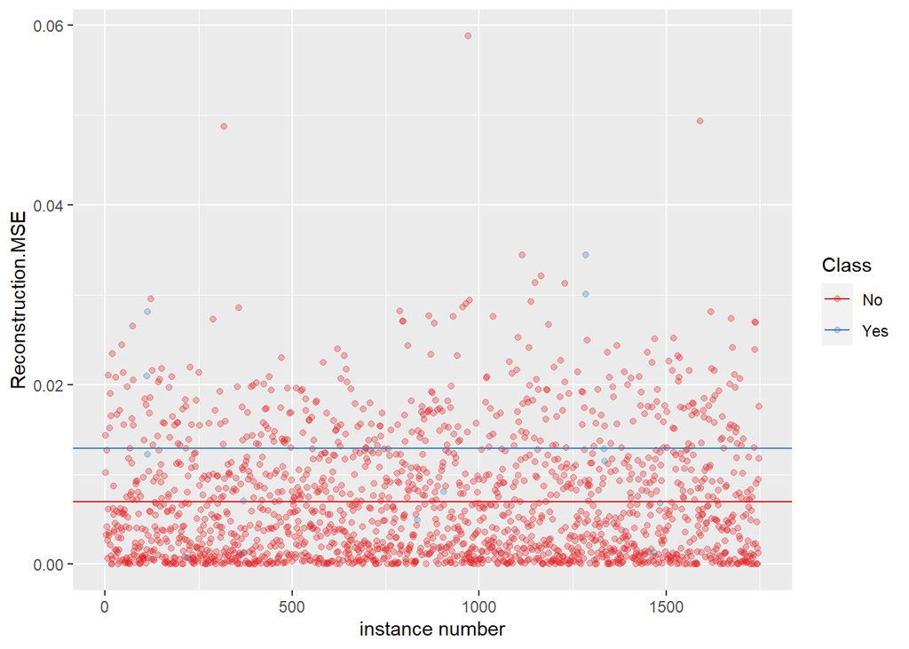

```r
anomaly <- h2o.anomaly(model_nn, test) %>%
  as.data.frame() %>%
  tibble::rownames_to_column() %>%
  mutate(Class = as.vector(test[, 4]))

mean_mse <- anomaly %>%
  group_by(Class) %>%
  summarise(mean = mean(Reconstruction.MSE))

threshold = quantile(anomaly$Reconstruction.MSE, probs = 0.995)

ggplot(anomaly, aes(x = as.numeric(rowname), y = Reconstruction.MSE, color = as.factor(Class))) +
  geom_point(alpha = 0.3) +
  geom_hline(data = mean_mse, aes(yintercept = mean, color = Class)) +
  scale_color_brewer(palette = "Set1") +
  labs(x = "instance number",
       color = "Class")
```

En la gráfica se observa que ésta vez la clasificación no es tan perfecta, aunque también se observa que las anomalías tienen el MSE más alto que el resto.

Ahora estableceremos como anomalías todo lo que supere un 0.02 de MSE.

```r
anomaly <- anomaly %>%
  mutate(predict = ifelse(Reconstruction.MSE > 0.02, "Yes", "No"))
names(anomaly)[3] = c("actual")

anomaly %>%
  group_by(actual, predict) %>%
  summarise(n = n()) %>%
  mutate(freq = n / sum(n))
```

```
## # A tibble: 4 x 4
## # Groups:   actual [2]
##   actual predict     n   freq
##   <chr>  <chr>   <int>  <dbl>
## 1 No     No       1644 0.948
## 2 No     Yes        91 0.0524
## 3 Yes    No         10 0.714
## 4 Yes    Yes         4 0.286
```

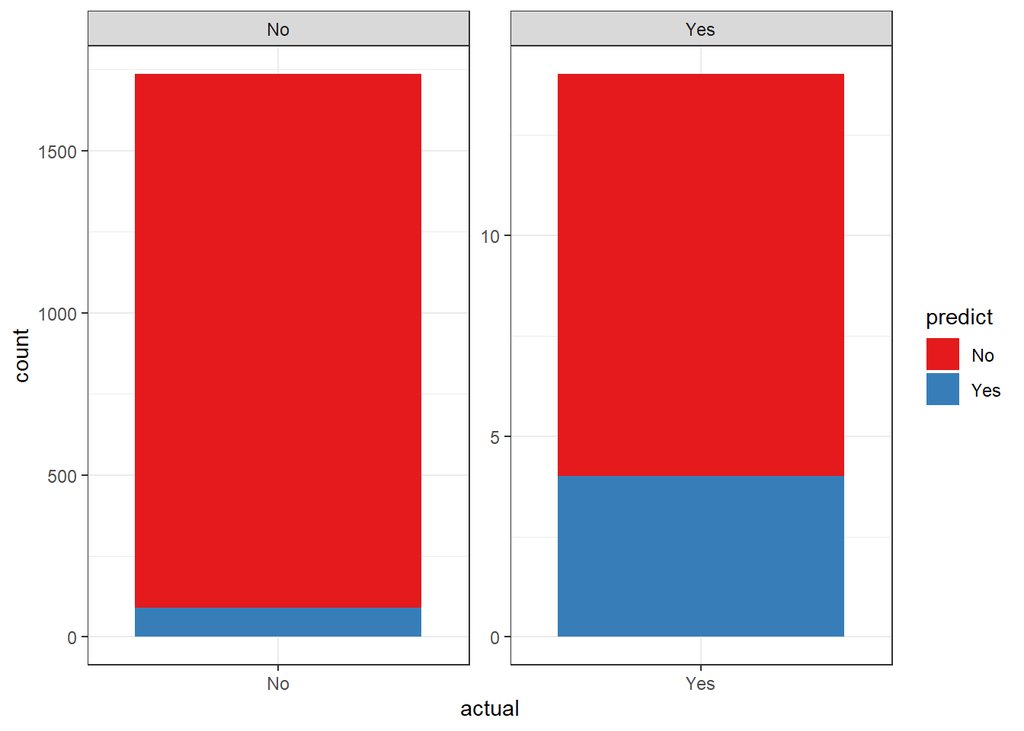

```r
anomaly %>%
  ggplot(aes(x = actual, fill = predict)) +
    geom_bar() +
    theme_bw() +
    scale_fill_brewer(palette = "Set1") +
    facet_wrap( ~ actual, scales = "free", ncol = 2)
```

### Reducción de dimensionalidad

Como ventaja, al utilizar una capa oculta de dos nodos, podemos utilizar los parametros de esta capa como una reducción de dimensionalidad - similar a análisis de coponentes principales (PCA) - ya que se habrá reducido unicamente a dos parámetros.

Podemos extraer esos parametros y ver como está agrupando nuestro modelo.

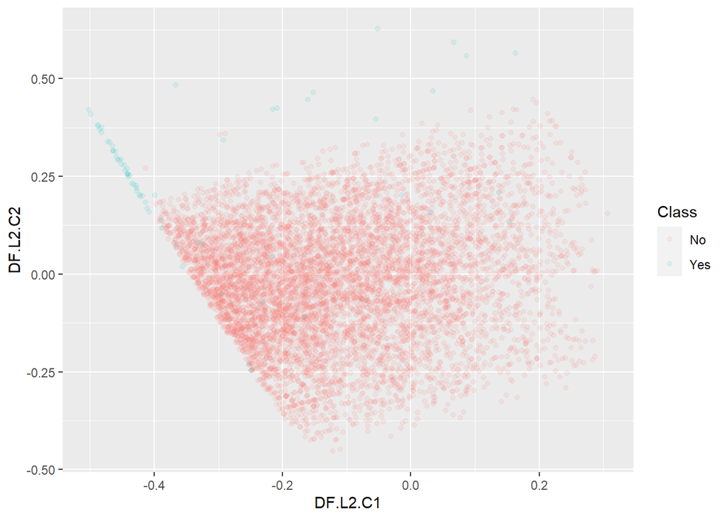

```r
train_features <- h2o.deepfeatures(model_nn, train, layer = 2) %>%
  as.data.frame() %>%
  mutate(Class = as.vector(train[, 4]))

ggplot(train_features, aes(x = DF.L2.C1, y = DF.L2.C2, color = Class)) +
  geom_point(alpha = 0.1)
```

Como podemos ver, parece que el modelo separa las dos clases adecuadamente - aunque también se solapan algunas observaciones - el resultado parece prometedor.

Veamos como se desenvuelve en una red neuronal esta reducción de dimensionalidad.

```r
train_features <- h2o.deepfeatures(model_nn, train, layer = 2) %>%
  as.data.frame() %>%
  mutate(Class = as.factor(as.vector(train[, 4]))) %>%
  as.h2o()
features_dim <- setdiff(colnames(train_features), response)

model_nn_dim <- h2o.deeplearning(y = "Class",
                               x = features_dim,
                               training_frame = train_features,
                               reproducible = TRUE,
                               balance_classes = TRUE,
                               ignore_const_cols = FALSE,
                               seed = 42,
                               hidden = c(10, 2, 10),
                               epochs = 100,
                               activation = "Tanh")
test_dim <- h2o.deepfeatures(model_nn, test, layer = 2)

pred <- as.data.frame(h2o.predict(object = model_nn_dim, newdata = test_dim)) %>%
  mutate(actual = as.vector(test[, 4]))

pred %>%
  group_by(actual, predict) %>%
  summarise(n = n()) %>%
  mutate(freq = n / sum(n))
```

```
## # A tibble: 4 x 4
## # Groups:   actual [2]
##   actual predict     n   freq
##   <chr>  <fct>   <int>  <dbl>
## 1 No     No       1649 0.950
## 2 No     Yes        86 0.0496
## 3 Yes    No          2 0.143
## 4 Yes    Yes        12 0.857
```

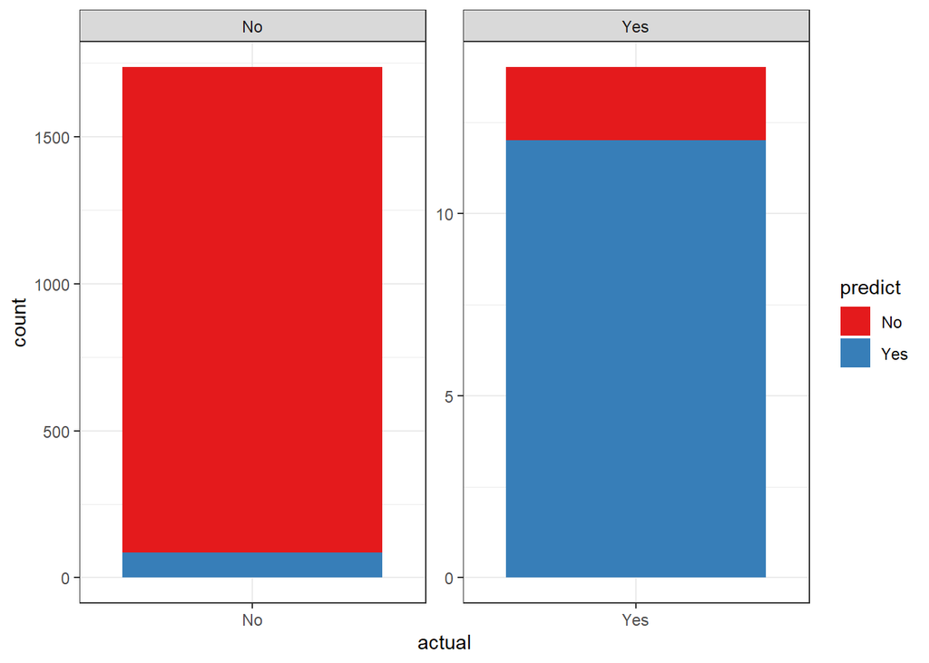

```r
pred %>%
  ggplot(aes(x = actual, fill = predict)) +
    geom_bar() +
    theme_bw() +
    scale_fill_brewer(palette = "Set1") +
    facet_wrap( ~ actual, scales = "free", ncol = 2)
```

## Modelo con RandomForest

En este módelo, así como los anteriores, tratatemos de clasificar los diferentes registros según sus valores, así que aplicaremos los modelos y lo contrastaremos con los datos de test.

```r
model_rf <- h2o.randomForest(y = response,
                             x = features,
                             training_frame = train,
                             ntrees = 100,
                             max_depth = 15,
                             nbins_cats = 1115,
                             validation_frame = test)

pred <- as.data.frame(h2o.predict(object = model_rf, newdata = test)) %>%
  mutate(actual = as.vector(test[, 4]))

pred %>%
  group_by(actual, predict) %>%
  summarise(n = n()) %>%
  mutate(freq = n / sum(n))
```

```
## # A tibble: 3 x 4
## # Groups:   actual [2]
##   actual predict     n  freq
##   <chr>  <fct>   <int> <dbl>
## 1 No     No       1735 1
## 2 Yes    No          3 0.214
## 3 Yes    Yes        11 0.786
```

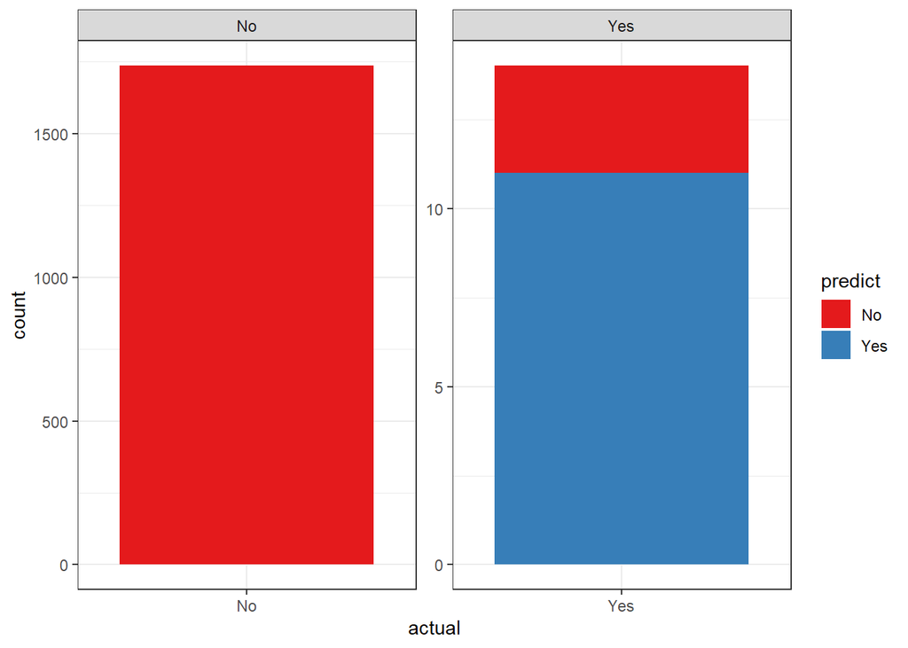

```r
pred %>%
  ggplot(aes(x = actual, fill = predict)) +
    geom_bar() +
    theme_bw() +
    scale_fill_brewer(palette = "Set1") +
    facet_wrap( ~ actual, scales = "free", ncol = 2)
```

## Modelo con máquinas de soporte vectorial (SVM)

```r
model_svm <- h2o.psvm(gamma = 0.01,
                      rank_ratio = 0.1,
                      y = response,
                      training_frame = train,
                      validation_frame = test,
                      seed = 42,
                      disable_training_metrics = FALSE)

pred <- as.data.frame(h2o.predict(object = model_svm, newdata = test)) %>%
  mutate(actual = as.vector(test[, 4]))

pred %>%
  group_by(actual, predict) %>%
  summarise(n = n()) %>%
  mutate(freq = n / sum(n))
```

```
## # A tibble: 4 x 4
## # Groups:   actual [2]
##   actual predict     n    freq
##   <chr>  <fct>   <int>   <dbl>
## 1 No     No       1733 0.999
## 2 No     Yes         2 0.00115
## 3 Yes    No          4 0.286
## 4 Yes    Yes        10 0.714
```

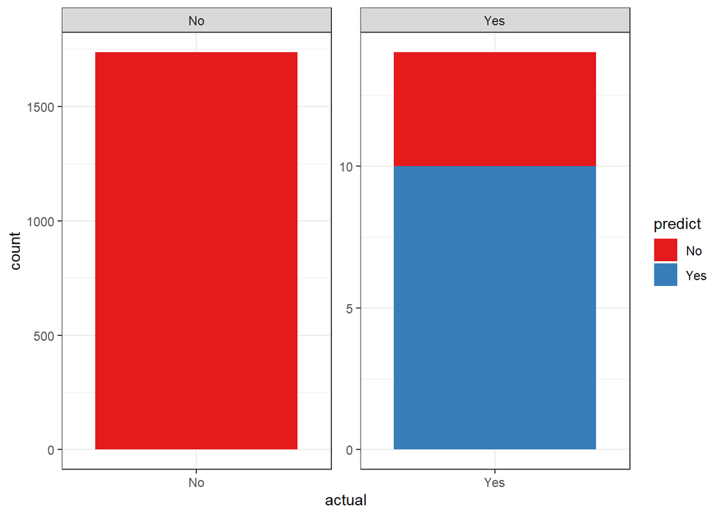

```r
pred %>%
  ggplot(aes(x = actual, fill = predict)) +
    geom_bar() +
    theme_bw() +
    scale_fill_brewer(palette = "Set1") +
    facet_wrap( ~ actual, scales = "free", ncol = 2)
```

## Modelo con K Means

```r
model_km <- h2o.kmeans(k = 2,
                      standardize = FALSE,
                      seed = 42,
                      x = features,
                      training_frame = train,
                      validation_frame = test)

pred <- as.data.frame(h2o.predict(object = model_km, newdata = test)) %>%
  mutate(actual = as.vector(test[, 4]))

pred %>%
  group_by(actual, predict) %>%
  summarise(n = n()) %>%
  mutate(freq = n / sum(n))
```

```
## # A tibble: 4 x 4
## # Groups:   actual [2]
##   actual predict     n  freq
##   <chr>    <int> <int> <dbl>
## 1 No           0   722 0.416
## 2 No           1  1013 0.584
## 3 Yes          0     3 0.214
## 4 Yes          1    11 0.786
```